# Play & Learning Across a Year (PLAY)

2022-04-08 15:45:56

## Acknowledgements

- Support from NICHD, NIH OD, NIMH, NIDA, OBSSR, NSF
- Karen Adolph, Cathie Tamis-LeMonda, Orit Hertzberg, Tiger Teng

## Overview

- What is PLAY
- Why PLAY
- Challenges to face
- Challenges met
- Challenges yet-to-be-met
- A preview

## What is PLAY

- 1,000 mother-infant dyads (12-, 18-, 24-mos)
- 1 hr natural behavior (video)
- 5 min structured play (video)
- House tour (video)
- Parent-report questionnaires
- Foundational video coding passes
  - Speech & language
  - Emotional expression
  - Object interaction
  - Locomotion & physical activity
- Common, shared data
- Rigorous QA control
- But investigator-specific questions…
- Dataset as deliverable
- Catalyze/expand capacity to exploit video

## Why PLAY

## Natural behavior

## Big data developmental science

## Open science

- Full transparency
- Re-useability

## Challenges to face

## Sampling

- Age range(s)
- What language backgrounds…
- Where to sample…
- What to vary, what to keep constant…
- Is ‘an hour in the life’ representative?

## Challenges met

- Only English and Spanish
- Informed by Census demographics

## Challenges yet-to-be-met

- Findable, useable beyond launch group
- Limitations of Databrary 1.0
  - Virtual volumes?
- Versioning data, protocol, coding scheme
- Add-on, follow-up studies
  - New data
  - Augmented, new annotations

## A preview

## Databrary

https://nyu.databrary.org/volume/444/slot/18825/-?asset=85849

## 1-hour natural play

https://nyu.databrary.org/slot/18825/78777000,82445800/asset/85849/download?inline=true

## House walk-through

https://nyu.databrary.org/slot/18825/69908000,70431136/asset/85853/download?inline=true

## Structured play

https://nyu.databrary.org/slot/18825/85767000,86228590/asset/85865/download?inline=true

## Parent-report questionnaires

https://nyu.databrary.org/slot/18825/82179000,85191864/asset/85867/download?inline=true

## Load PLAY survey data

```
databraryapi::login_db("myemail@university.edu")
play_data <- databraryapi::read_csv_data_as_df(session_id = 51539, asset_id = 365016)
```

## Demographics

```
xtabs(formula = ~ child_sex + age_group, data = play_data) %>%
  knitr::kable(., format = 'html') %>%
  kableExtra::kable_classic(.)
```

|  | 12mo | 18mo | 24mo |
| --- | --- | --- | --- |
| female | 11 | 13 | 5 |
| male | 7 | 6 | 12 |

```
xtabs(formula = ~ child_race + child_ethnicity, data = play_data) %>%
  knitr::kable(., format = 'html') %>%
  kableExtra::kable_classic(.)
```

|  | Hispanic or Latino | Not Hispanic or Latino |
| --- | --- | --- |
| Asian | 0 | 1 |
| Black or African American | 1 | 0 |
| More than one | 8 | 4 |
| Other | 0 | 1 |
| White | 3 | 36 |

## Locomotor milestones

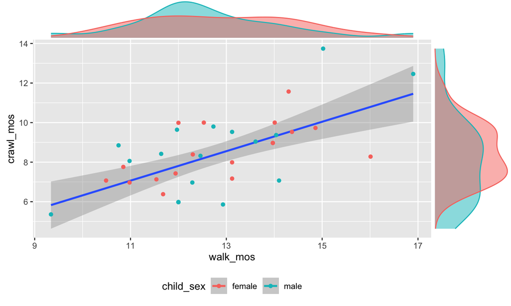

## Feeding

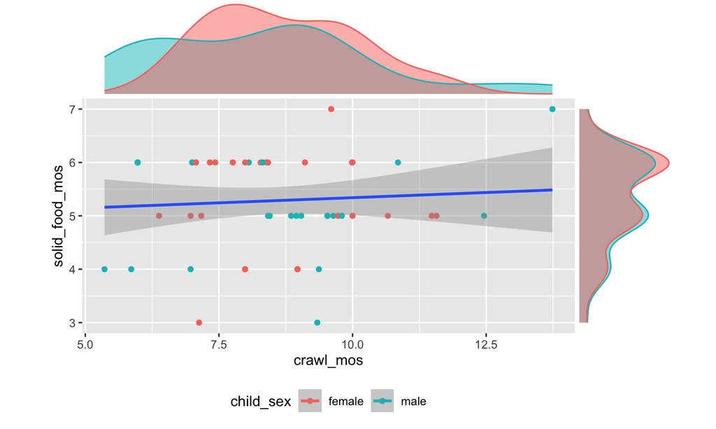

```
## [1] TRUE
```

[video not shown]

rog1@psu.edu

https://play-project.org  
https://gilmore-lab.github.io